# Visualizing high dimensional data

Cory Whitney, Eduardo Fernandez

2019-07-25

Dealing with large data sets can sometimes be confusing. If you are working in spreadsheets the confusion can reach the point of existential crises bordering on pure chaos. Good visualition tools can help. Visualization can allow you to get an overview of your data. It can also help you report patterns and differences in your data.

Needless to say any aims objectives and hypotheses should be determined before any data is collected. Data visualization is a good time to get a clear sense for how your data looks, but is not the time to start making up hypotheses about it.

Here we demonstrate a few different approaches for data visualization. We do this for several types of high dimensional data using plotting functions from `tidyverse` libraries including `ggplot2`, `plyr` and `dplyr` among others in the [R programming language](https://www.r-project.org/).

## Radial bar plots

Becuase plots of high dimensional data do not always need an x-axis we sometimes compress it to a point using [polar coordinates](https://ggplot2.tidyverse.org/reference/coord_polar.html). For showing off options for radial bar plots we created an example data set with a factor variable using the `data.frame` and `sample` functions in base R.

```r
DF <- data.frame(variable = as.factor(1:10),
                 value = sample(10, replace = TRUE))
```

We also created a function to compute the standard error of the mean to represent some of the uncertainty in the data using the `sqrt` and `length` functions in base R and the `var` from the `stats` library.

```r
se <- function(x) sqrt(var(x)/length(x))
```

Create a radial bar plot using the functions above and the `ggplot2` library.

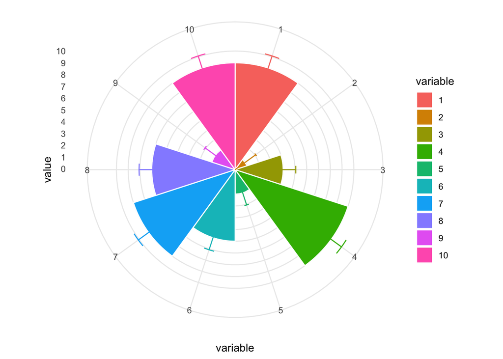

```r
ggplot(DF, aes(variable, value, fill = variable)) +
  geom_bar(width = 1, stat = "identity", color = "white") +
  geom_errorbar(aes(ymin = value - se(DF$value),
                    ymax = value + se(DF$value),
                    color = variable),
                width = .2) +
  scale_y_continuous(breaks = 0:nlevels(DF$variable)) +
  theme_minimal() +
  coord_polar()
```

### Radial bar plots with a number of factor variables

Create a data set for radial plots with with three factor variables

```r
DF2 <- data.frame(name = rep(letters[1:3], length.out = 30),
                 variable = as.factor(1:5),
                 factor_variable = rep(letters[4:7], length.out = 30),
                 value = sample(10, replace = TRUE))
```

Plot radial plots with three factor variables

```r
multi_plot <- ggplot(DF2, aes(variable, value, fill = variable)) +
  geom_bar(width = 1, stat = "identity", color = "white") +
  geom_errorbar(aes(ymin = value - se(DF2$value),
                    ymax = value + se(DF2$value),
                    color = variable),
                width = .2) +
  scale_y_continuous(breaks = 0:nlevels(DF2$variable)) +
  theme_minimal() +
  coord_polar()
```

Plot with rows as names and columns as variables `factor_variable`

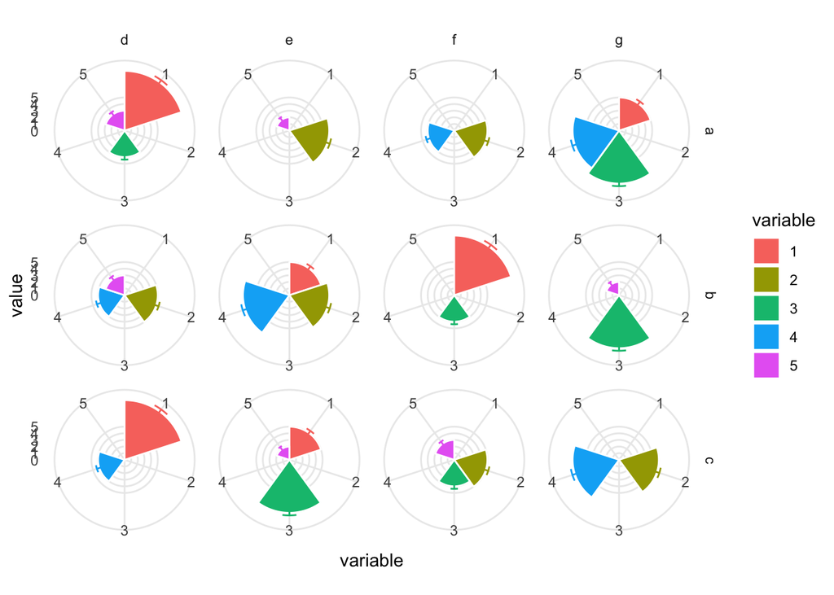

```r
# Rows are name and columns are factor_variable
multi_plot + facet_grid(name ~ factor_variable)
```

Plot with bars going around the circle

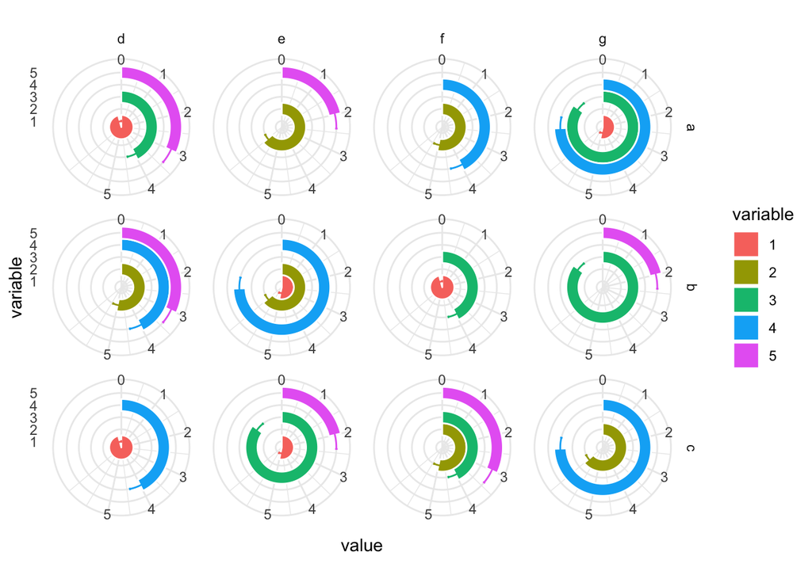

```r
# Rows are name and columns are factor_variable
multi_plot +
  coord_polar(theta="y")+
  facet_grid(name ~ factor_variable)
```

More on making polar barplots from [this blog](http://rstudio-pubs-static.s3.amazonaws.com/72298_c1ba7f77276a4f27a0f375cadc9fac5d.html)

## Radial box plots

To show a radial box plot with a data set and grid with four factor variables and one continuous.

```r
DF3 <- data.frame(name = rep(letters[1:3], length.out = 600),
                  variable = as.factor(sample(5, replace = TRUE)),
                  factor_variable = rep(letters[4:7], length.out = 600),
                  variable3 = rep(letters[8:16], length.out = 600),
                  value = sample(50, replace = TRUE))
```

Plot with `ggplot2` functions

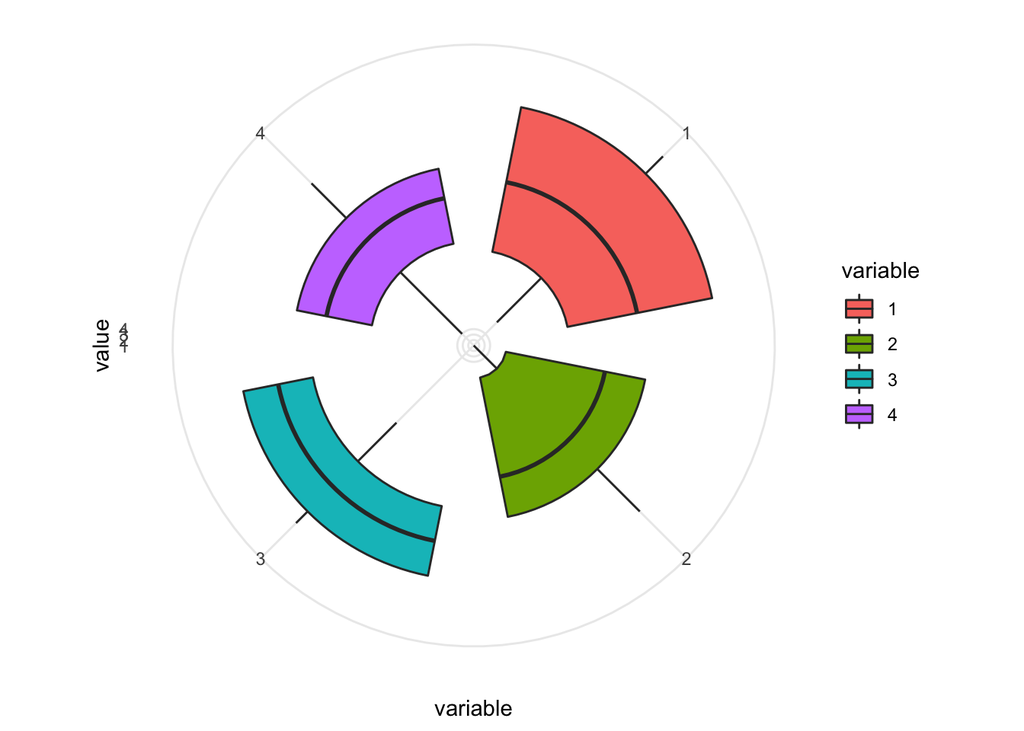

```r
multi_plot <- ggplot(data = DF3, aes(x=variable, y=value, fill=variable)) +
  geom_boxplot() +
  scale_y_continuous(breaks = 0:nlevels(DF3$variable)) +
  theme_minimal() +
  coord_polar()

#call the plot
multi_plot
```

Radial box plot with rows as names and columns as variables for `factor_variable`.

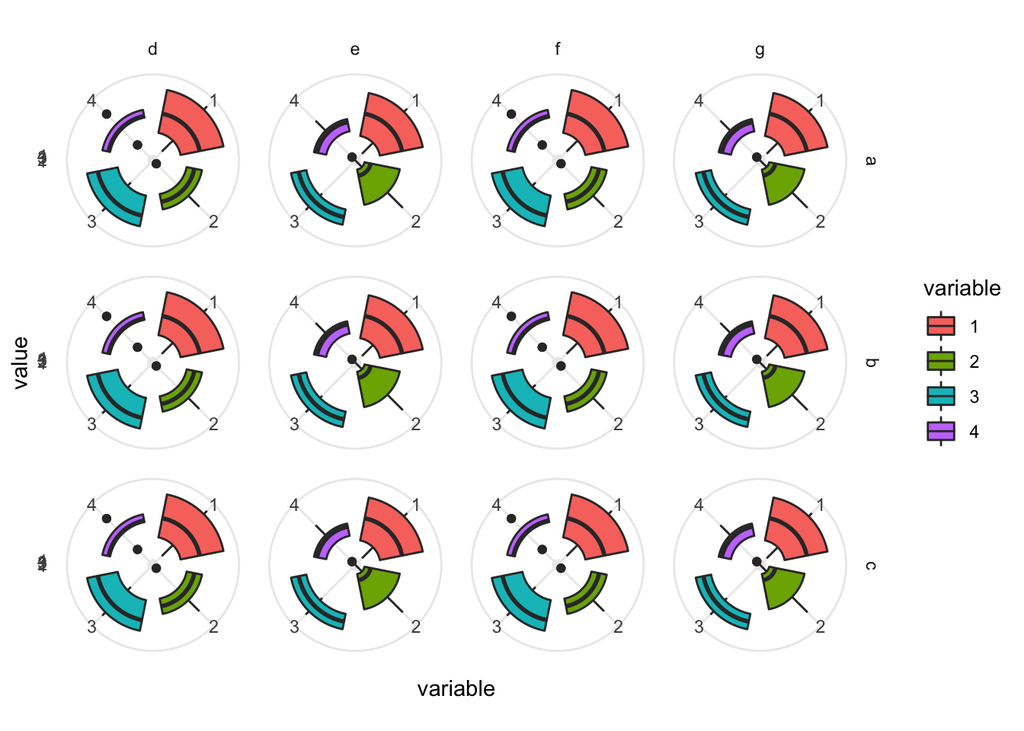

```r
multi_plot + facet_grid(name ~ factor_variable)
```

### Radial box plots example using `ToothGrowth` data

```r
ToothGrowth$dose <- as.factor(ToothGrowth$dose)
DF4 <- ToothGrowth
head(DF4)
```

```
##    len supp dose
## 1  4.2   VC  0.5
## 2 11.5   VC  0.5
## 3  7.3   VC  0.5
## 4  5.8   VC  0.5
## 5  6.4   VC  0.5
## 6 10.0   VC  0.5
```

```r
box_plot <- ggplot(DF4, aes(x=dose, y=len, group=dose)) +
  geom_boxplot(aes(fill=dose)) +
  theme_minimal()+
  coord_polar()
```

Split the radial boxplot in a vertically

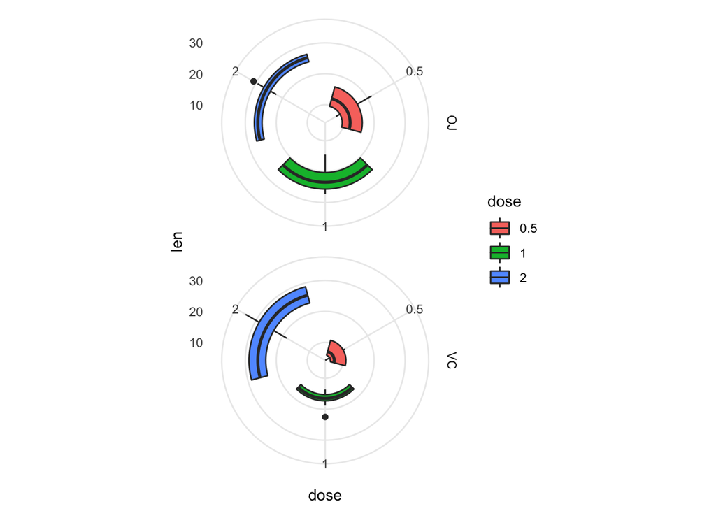

```r
#
box_plot + facet_grid(supp ~ .)
```

Split the radial boxplot horizontally

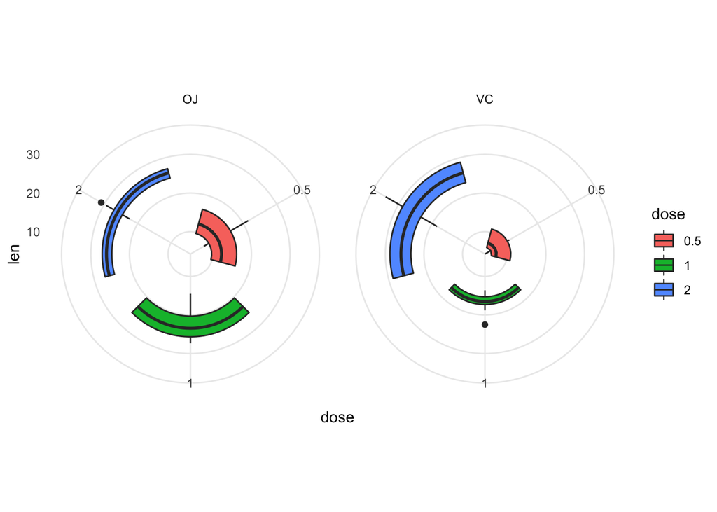

```r
box_plot + facet_grid(. ~ supp)
```

## Sunburst plot

To demonstrate a sunburst-style barplot confined to a circle we create small data set using `data.frame`.

Here is a thread about some more helpful options and scripts for making [sunbursts and donut plots](https://stackoverflow.com/questions/26748069/ggplot2-pie-and-donut-chart-on-same-plot).

```r
DF5 <- data.frame(
  'level1'=c('a', 'a', 'a', 'a', 'b', 'b', 'c', 'c', 'c'),
  'level2'=c('a1', 'a2', 'a3', 'a4', 'b1', 'b2', 'c1', 'c2', 'c3'),
  'value'=c(.025, .05, .027, .005, .012, .014, .1, .03, .18))
```

Create a sunburst-style barplot confined to a circle

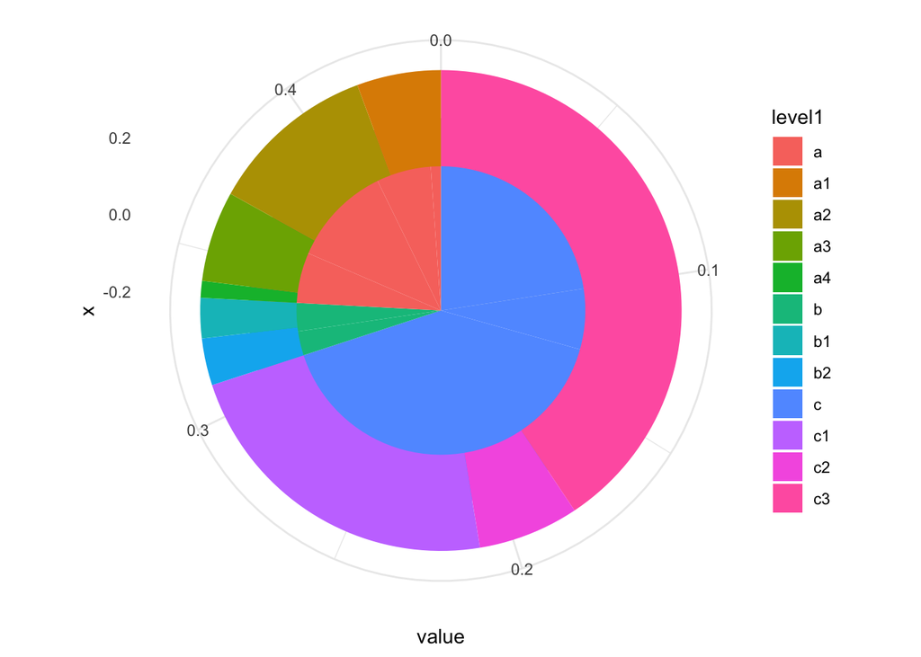

```r
ggplot(DF5, aes(y=value)) +
  geom_bar(aes(fill=level1, x=0), width=.5, stat='identity') +
  geom_bar(aes(fill=level2, x=.25), width=.25, stat='identity') +
  coord_polar(theta='y') +
  theme_minimal()
```

## Spider plot

To demonstrate the spider plot data visualization we use a function<sup>1</sup> to obtain straight lines using `match.arg` from base R.

```r
coord_radar <-
  function(theta = 'x', start = 0, direction = 1){
    # input parameter sanity check
    match.arg(theta, c('x', 'y'))

    ggproto(
      NULL, CoordPolar,
      theta = theta, r = ifelse(theta == 'x', 'y', 'x'),
      start = start, direction = sign(direction),
      is_linear = function() TRUE)
  }
```

Create a factor, variable, and value to be plotted in the spider plot using base R functions.

```r
factor <- c(rep("A", 16), rep("B", 16))
variable <- as.factor(c(1:16))
value <- sample(c(1:10), 32, replace = T)
```

In order to neatly close the plot we add an empty level to the data set (a quasi-blank variable) which needs the same value as level 1. For this to work both factors (“A” and “B” in our case) need this correction.

```r
value[16] <- value[1]
value[32] <- value[17]
```

We add the factor, variable, and value together with the blank variable to a data set using `data.frame`.

```r
data <- data.frame(factor = factor, variable = variable, value = value)
```

Plot with the `ggplot2` library.

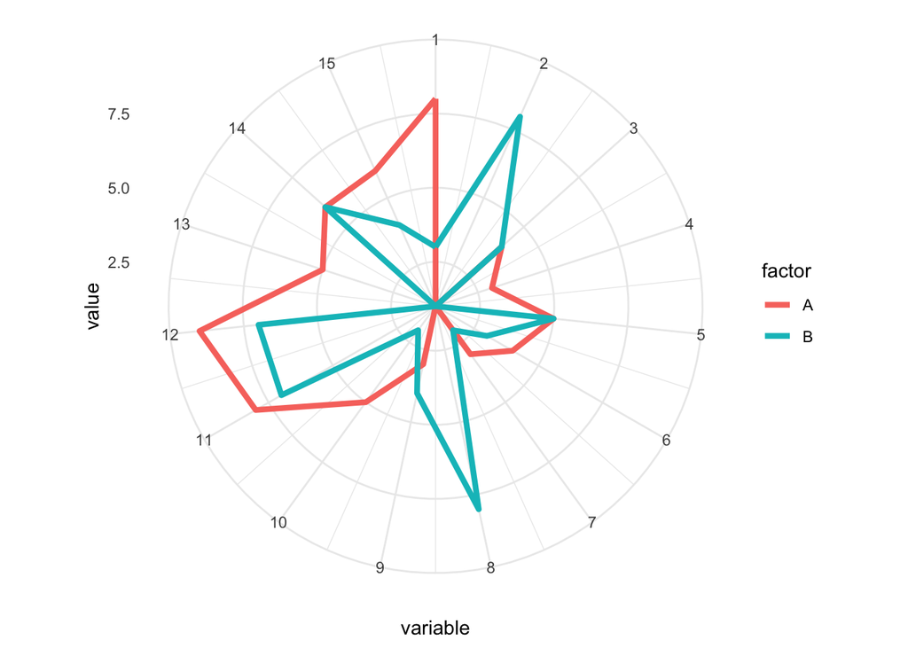

```r
ggplot(data, aes(as.numeric(data$variable), value, colour = factor)) +
  coord_radar() +
  geom_path(size = 1.5) + scale_x_continuous(breaks = c(1:15)) +
  labs(x = "variable") +
  theme_minimal()
```

## Violin plot with boxplot overlays and ridgeline plots using `OrchardSprays` data

From the `tidyverse` [Violin plot](https://ggplot2.tidyverse.org/reference/geom_violin.html) examples

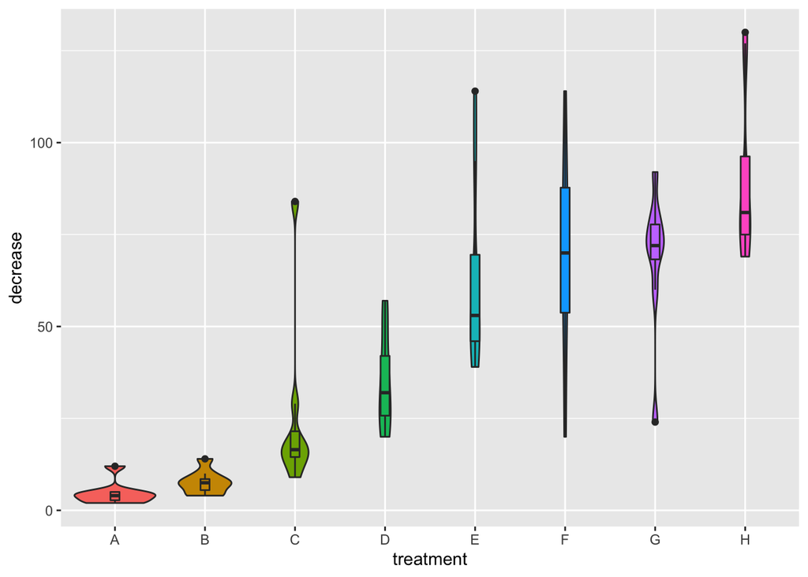

```r
ggplot(OrchardSprays, aes(y=decrease, x=treatment, fill=treatment))+
  geom_violin()+
  geom_boxplot(width=0.1)+
  theme(legend.position = "none")
```

### Ridgeline plot

A variation on the example from [edav](https://edav.info/ridgeline.html) using the `ggridges` library.

More examples from [CRAN](https://rdrr.io/cran/ggridges/man/geom_ridgeline_gradient.html)

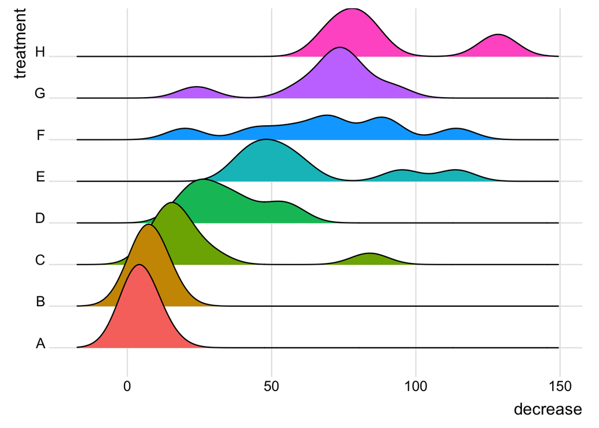

```r
ggplot(OrchardSprays, aes(x=decrease,y=treatment,fill=treatment))+
  geom_density_ridges_gradient(scale=2) + theme_ridges()+
  theme(legend.position = "none")
```

## References and resources

<sup>1</sup>The `coord_radar()` function was taken from the question “Closing the lines in a ggplot2 radar / spider chart” from stacko verflow website. https://stackoverflow.com/questions/28898143/closing-the-lines-in-a-ggplot2-radar-spider-chart